# Arboles de decisión con carros

2024-03-07

```r
library(GGally)
library(nortest)
library(dplyr)
library(tidyverse)
library(rpart)
library(rpart.plot)
library(caret)
library(discretization)
```

## Descripción variables carros

*Número de filas:* 205  
*Número de atributos o columnas:* 26

### Información de los atributos:

| Atributo: | Rango del atributo: |
| --- | --- |
| 1. symboling: | -3, -2, -1, 0, 1, 2, 3. |
| 2. normalized-losses: | numérico 65 hasta 256. |
| 3. make: | alfa-romero, audi, bmw, chevrolet, dodge, honda, isuzu, jaguar, mazda, mercedes-benz, mercury, mitsubishi, nissan, peugot, plymouth, porsche, renault, saab, subaru, hastayota, volkswagen, volvo |
| 4. fuel-type: | diesel, gas. |
| 5. aspiration: | std, turbo. |
| 6. num-of-doors: | four, two. |
| 7. body-style: | hardtop, wagon, sedan, hatchback, convertible. |
| 8. drive-wheels: | 4wd, fwd, rwd. |
| 9. engine-location: | front, rear. |
| 10. wheel-base: | numérico desde 86.6 hasta 120.9. |
| 11. length: | numérico desde 141.1 hasta 208.1. |
| 12. width: | numérico desde 60.3 hasta 72.3. |
| 13. height: | numérico desde 47.8 hasta 59.8. |
| 14. curb-weight: | numérico desde 1488 hasta 4066. |
| 15. engine-type: | dohc, dohcv, l, ohc, ohcf, ohcv, rotor. |
| 16. num-of-cylinders: | eight, five, four, six, three, twelve, two. |
| 17. engine-size: | numérico desde 61 to 326. |
| 18. fuel-system: | 1bbl, 2bbl, 4bbl, idi, mfi, mpfi, spdi, spfi. |
| 19. bore: | numérico desde 2.54 hasta 3.94. |
| 20. stroke: | numérico desde 2.07 hasta 4.17. |
| 21. compression-ratio: | numérico desde 7 hasta 23. |
| 22. horsepower: | numérico desde 48 hasta 288. |
| 23. peak-rpm: | numérico desde 4150 hasta 6600. |
| 24. city-mpg: | numérico desde 13 hasta 49. |
| 25. highway-mpg: | numérico desde 16 hasta 54. |
| 26. price: | numérico desde 5118 hasta 45400. |

```r
summary(carros)
```

```
##    symboling       normalized_losses     make            fuel_type
##  Min.   :-2.0000   Min.   : 65       Length:205         Length:205
##  1st Qu.: 0.0000   1st Qu.: 94       Class :character   Class :character
##  Median : 1.0000   Median :115       Mode  :character   Mode  :character
##  Mean   : 0.8341   Mean   :122
##  3rd Qu.: 2.0000   3rd Qu.:150
##  Max.   : 3.0000   Max.   :256
##                    NA's   :41
##   aspiration        num_of_doors        body_style        drive_wheels
##  Length:205         Length:205         Length:205         Length:205
##  Class :character   Class :character   Class :character   Class :character
##  Mode  :character   Mode  :character   Mode  :character   Mode  :character
##
##
##
##
##  engine_location      wheel_base         length          width
##  Length:205         Min.   : 86.60   Min.   :141.1   Min.   :60.30
##  Class :character   1st Qu.: 94.50   1st Qu.:166.3   1st Qu.:64.10
##  Mode  :character   Median : 97.00   Median :173.2   Median :65.50
##                     Mean   : 98.76   Mean   :174.0   Mean   :65.91
##                     3rd Qu.:102.40   3rd Qu.:183.1   3rd Qu.:66.90
##                     Max.   :120.90   Max.   :208.1   Max.   :72.30
##
##      height       curb_weight   engine_type        num_of_cylinders
##  Min.   :47.80   Min.   :1488   Length:205         Length:205
##  1st Qu.:52.00   1st Qu.:2145   Class :character   Class :character
##  Median :54.10   Median :2414   Mode  :character   Mode  :character
##  Mean   :53.72   Mean   :2556
##  3rd Qu.:55.50   3rd Qu.:2935
##  Max.   :59.80   Max.   :4066
##
##   engine_size    fuel_system             bore          stroke
##  Min.   : 61.0   Length:205         Min.   :2.54   Min.   :2.070
##  1st Qu.: 97.0   Class :character   1st Qu.:3.15   1st Qu.:3.110
##  Median :120.0   Mode  :character   Median :3.31   Median :3.290
##  Mean   :126.9                      Mean   :3.33   Mean   :3.255
##  3rd Qu.:141.0                      3rd Qu.:3.59   3rd Qu.:3.410
##  Max.   :326.0                      Max.   :3.94   Max.   :4.170
##                                     NA's   :4      NA's   :4
##  compression_ratio   horsepower       peak_rpm       city_mpg
##  Min.   : 7.00     Min.   : 48.0   Min.   :4150   Min.   :13.00
##  1st Qu.: 8.60     1st Qu.: 70.0   1st Qu.:4800   1st Qu.:19.00
##  Median : 9.00     Median : 95.0   Median :5200   Median :24.00
##  Mean   :10.14     Mean   :104.3   Mean   :5125   Mean   :25.22
##  3rd Qu.: 9.40     3rd Qu.:116.0   3rd Qu.:5500   3rd Qu.:30.00
##  Max.   :23.00     Max.   :288.0   Max.   :6600   Max.   :49.00
##                    NA's   :2       NA's   :2
##   highway_mpg        price
##  Min.   :16.00   Min.   : 5118
##  1st Qu.:25.00   1st Qu.: 7775
##  Median :30.00   Median :10295
##  Mean   :30.75   Mean   :13207
##  3rd Qu.:34.00   3rd Qu.:16500
##  Max.   :54.00   Max.   :45400
##                  NA's   :4
```

## Árbol de decisión con todas las variables

Veamos cuales son las variables más importantes para determinar el consumo de millas por galón que es nuestra variable respuesta.

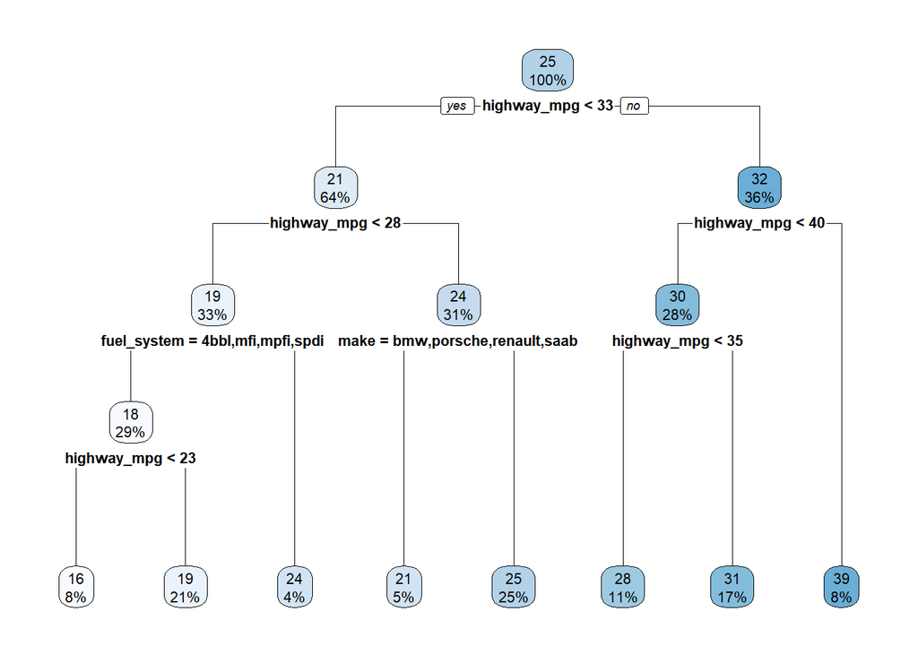

```r
arbol1 <- rpart(city_mpg~.,data = carros)
rpart.plot(arbol1)
```

Como podemos observar hay 3 variables importantes en el conjunto de datos, el consumo de millas por galón en carretera, la marca y el sistema ed combustible.

## Conjuntos de entrenamiento y prueba.

Se separarán en 70% de los datos en el conjunto de entrenamiento y 30% en el conjunto de prueba, usando un muestreo aleatorio simple.

```r
set.seed(245)
porciento <- 0.7
corte <- sample(nrow(carros),nrow(carros)*porciento)
train <- carros[corte,]
test <- carros[-corte,]
test_resp <- test$city_mpg
test$city_mpg <- NULL
```

## Modelo de árbol de regresión con parámetros por defecto.

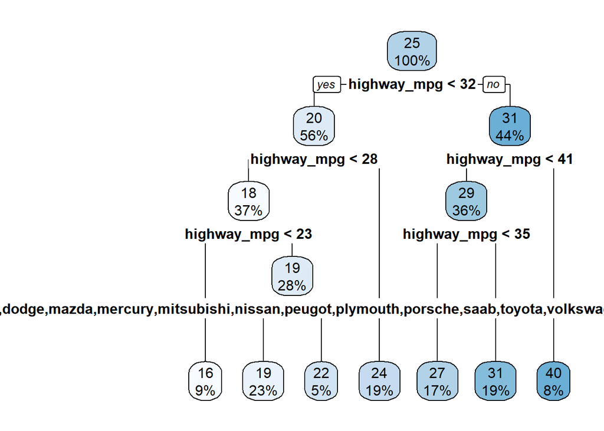

```r
modelo1 <- rpart(city_mpg~.,data = train)
rpart.plot(modelo1)
```

```r
predModelo1 <- predict(modelo1, newdata = test)
rmseModelo1test<-RMSE(predModelo1,test_resp)
mseModelo1test<-mean((predModelo1 - test_resp)^2)
predModelo1Train <- predict(modelo1, newdata = train[,-23])
rmseModelo1train<-RMSE(predModelo1Train,train$city_mpg)
mseModelo1train<-mean((predModelo1Train - train$city_mpg)^2)
```

El error medio cuadrado es 5.8514069 en el conjunto de prueba, mientras que el error de entrenamiento es 2.6975019.

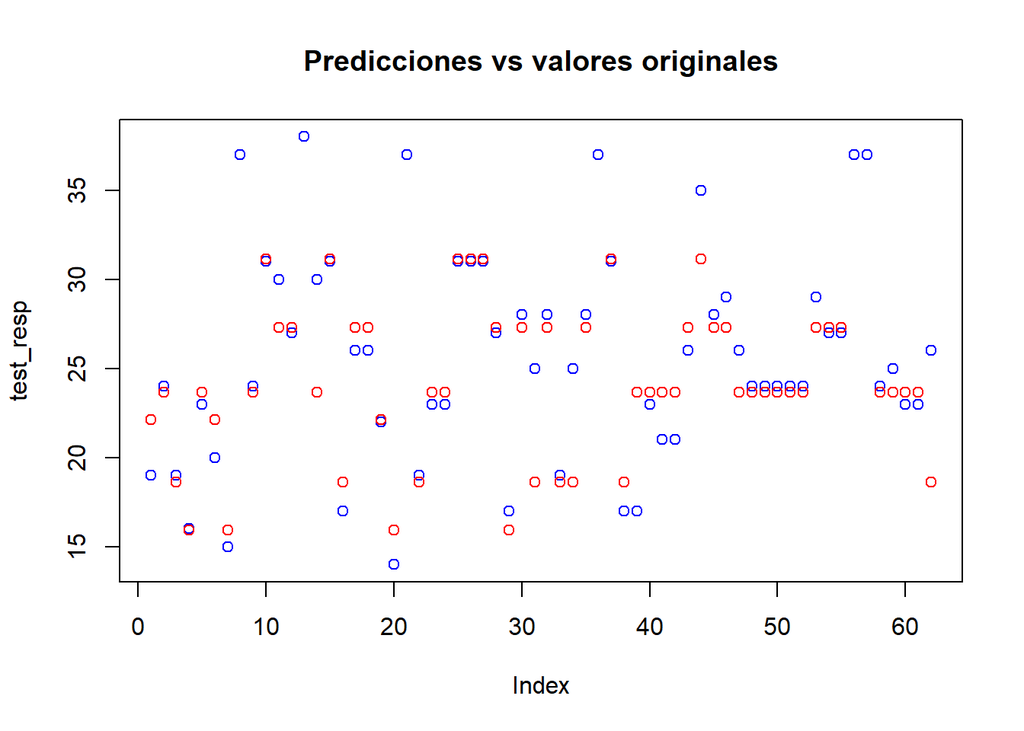

```r
plot(test_resp,col="blue", main="Predicciones vs valores originales")
points(predModelo1, col="red")
legend(30,45,legend=c("original", "prediccion"),col=c("blue", "red"),pch=1, cex=0.8)
```

No lo hizo tan mal el modelo, hagamos un modelo con validación cruzada.

## Modelo con validación cruzada y tuneando parámetros

```r
controlcv <- trainControl(method = "cv",number = 10)
modelo2<- train(city_mpg~.,data=train,
            method="rpart",
            trControl=controlcv,
            na.action=na.pass
            )
```

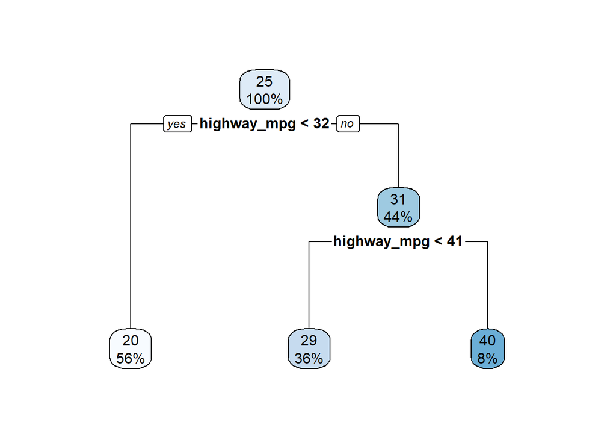

```r
rpart.plot(modelo2$finalModel)
```

```r
predModelo2 <- predict(modelo2, newdata = test)
rmseModelo2test<-RMSE(predModelo2,test_resp)
mseModelo2test<-mean((predModelo2 - test_resp)^2)

predModelo2Train <- predict(modelo2, newdata = train[,-23])
rmseModelo2train<-RMSE(predModelo2Train,train$city_mpg)
mseModelo2train<-mean((predModelo2Train - train$city_mpg)^2)
```

El error medio cuadrado es 11.2421273 en el conjunto de prueba, mientras que el error de entrenamiento es 77.9240724.

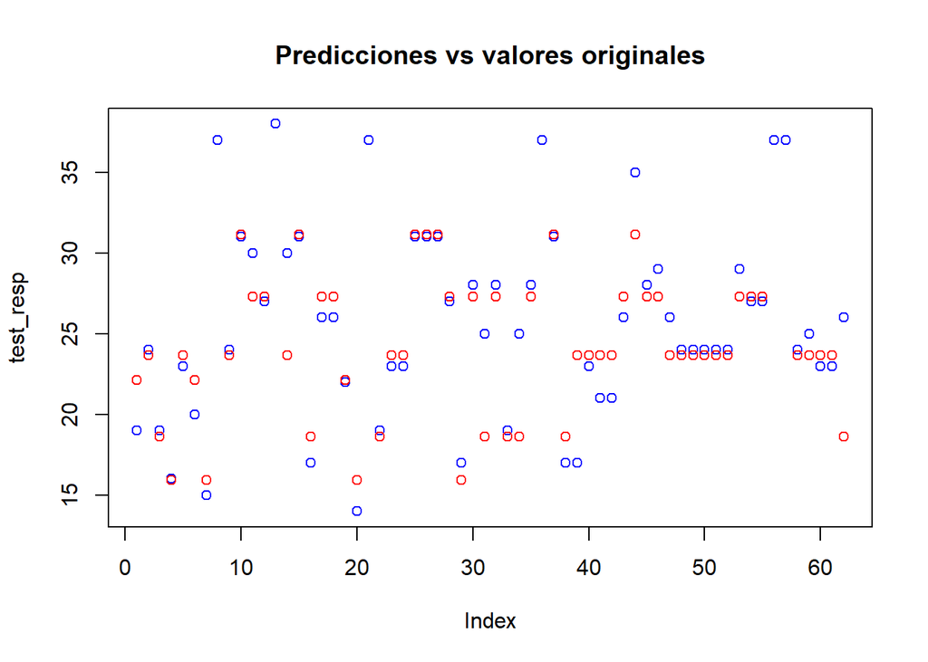

```r
plot(test_resp,col="blue", main="Predicciones vs valores originales")
points(predModelo1, col="red")
legend(30,45,legend=c("original", "prediccion"),col=c("blue", "red"),pch=1, cex=0.8)
```

### ¿Qué parametros podemos tunnear?

Podemos tunear los siguientes parámetros

```r
modelLookup("rpart")
```

```
##   model parameter                label forReg forClass probModel
## 1 rpart        cp Complexity Parameter   TRUE     TRUE      TRUE
```

```r
modelLookup("rpart2")
```

```
##    model parameter          label forReg forClass probModel
## 1 rpart2  maxdepth Max Tree Depth   TRUE     TRUE      TRUE
```

Trabajemos con rpart2 para probar varias profundidades del árbol y ver cual es el mejor modelo.

```r
profundidades <- data.frame(c(1,4,6,8,10))
names(profundidades)<-"maxdepth"
system.time(
modelo3<-train(city_mpg~.,
                data=train,
                method="rpart2",
                #tuneLength = 10,
                tuneGrid = profundidades,
                trControl = controlcv,
                metric = "RMSE",
                na.action = na.pass
               )
)
```

```
##    user  system elapsed
##    0.78    0.02    0.83
```

```r
modelo3
```

```
## CART
##
## 143 samples
##  24 predictor
##
## No pre-processing
## Resampling: Cross-Validated (10 fold)
## Summary of sample sizes: 129, 128, 129, 129, 128, 129, ...
## Resampling results across tuning parameters:
##
##   maxdepth  RMSE      Rsquared   MAE
##    1        4.093605  0.6581569  3.201692
##    4        2.060497  0.9303309  1.533325
##    6        1.996137  0.9297475  1.423238
##    8        1.996137  0.9297475  1.423238
##   10        1.996137  0.9297475  1.423238
##
## RMSE was used to select the optimal model using the smallest value.
## The final value used for the model was maxdepth = 6.
```

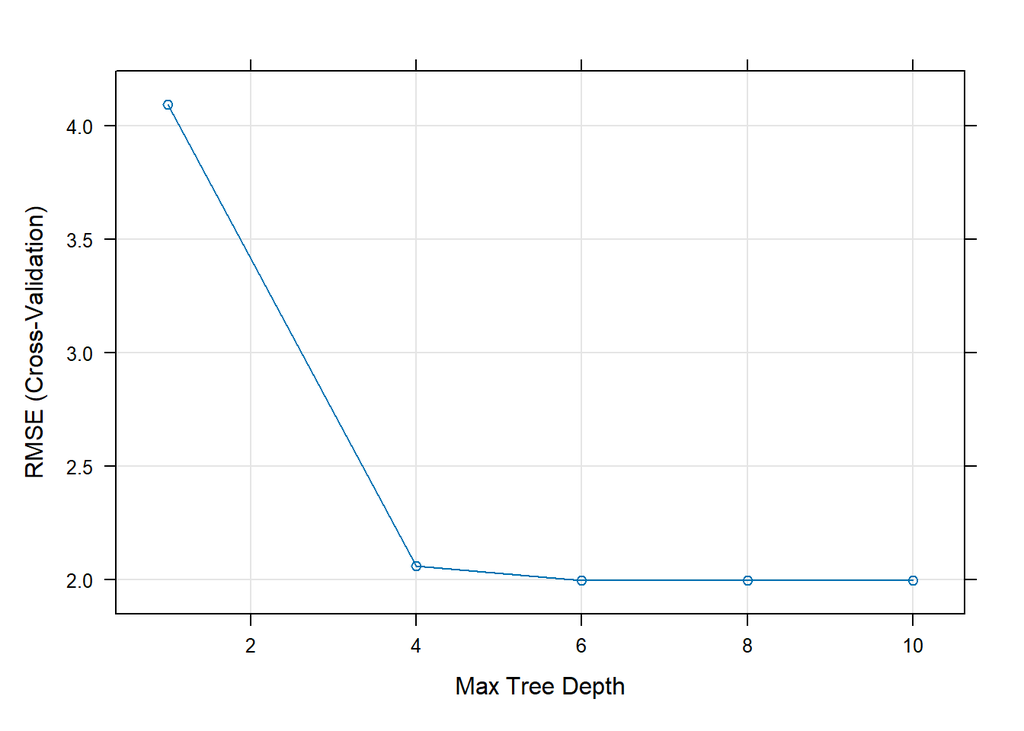

```r
plot(modelo3)
```

Como se puede observar luego de una profundidad de 6 no se mejora el rmse por lo que es el mejor valor de profundidad. Usemos grid serch cross validation para un mejor tuneo de parámetros.

```r
profundidades <- expand.grid(maxdepth = 2:10)

system.time (modelo3.1<-train(city_mpg~.,
                data=train,
                method="rpart2",
                tuneLength = 10,
                tuneGrid = profundidades,
                trControl = controlcv,
                metric = "RMSE",
                na.action = na.pass
               )
)
```

```
##    user  system elapsed
##    0.96    0.03    1.00
```

```r
modelo3.1
```

```
## CART
##
## 143 samples
##  24 predictor
##
## No pre-processing
## Resampling: Cross-Validated (10 fold)
## Summary of sample sizes: 129, 129, 128, 129, 127, 128, ...
## Resampling results across tuning parameters:
##
##   maxdepth  RMSE      Rsquared   MAE
##    2        3.108150  0.7864788  2.651513
##    3        2.280678  0.8977664  1.849131
##    4        2.039582  0.9197117  1.493173
##    5        1.894389  0.9286038  1.331223
##    6        1.894389  0.9286038  1.331223
##    7        1.894389  0.9286038  1.331223
##    8        1.894389  0.9286038  1.331223
##    9        1.894389  0.9286038  1.331223
##   10        1.894389  0.9286038  1.331223
##
## RMSE was used to select the optimal model using the smallest value.
## The final value used for the model was maxdepth = 5.
```

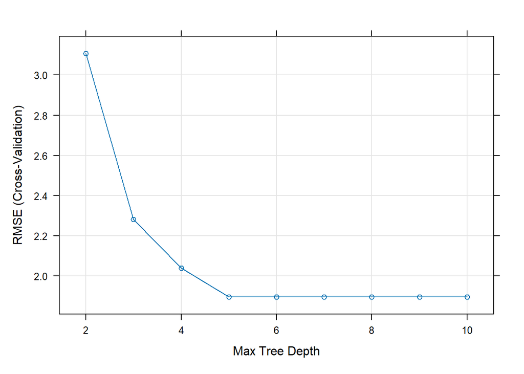

```r
plot(modelo3.1)
```

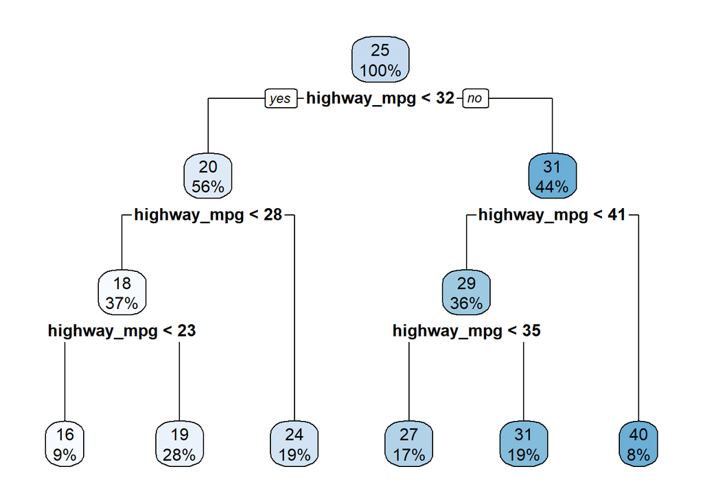

```r
rpart.plot(modelo3.1$finalModel)
```

Según el modelo greedy podemos usar todavía menos profundidad. Vamos a predecir con el modelo 3.1

```r
predModelo3.1 <- predict(modelo3.1, newdata = test)
rmseModelo3.1test<-RMSE(predModelo3.1,test_resp)
mseModelo3.1test<-mean((predModelo3.1 - test_resp)^2)

predModelo3.1Train <- predict(modelo3.1, newdata = train[,-23])
rmseModelo3.1train<-RMSE(predModelo3.1Train,train$city_mpg)
mseModelo3.1train<-mean((predModelo3.1Train - train$city_mpg)^2)
```

El error medio cuadrado es 5.4394294 en el conjunto de prueba, mientras que el error de entrenamiento es 81.6382737.

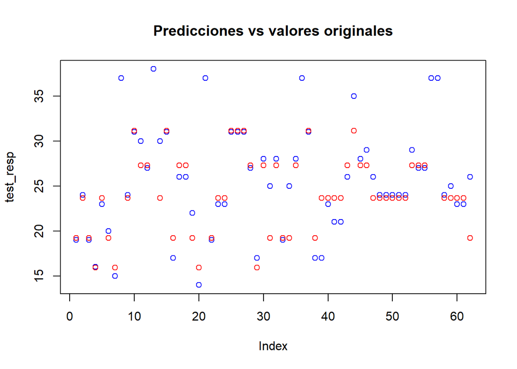

```r
plot(test_resp,col="blue", main="Predicciones vs valores originales")
points(predModelo3.1, col="red")
legend(30,45,legend=c("original", "prediccion"),col=c("blue", "red"),pch=1, cex=0.8)
```

## Comparación de modelos

```r
CompModelos<-c(rmseModelo1test,rmseModelo2test,rmseModelo3.1test)
names(CompModelos)<-c("Modelo1","Modelo2","Modelo3")
CompModelos
```

```
##  Modelo1  Modelo2  Modelo3
## 2.418968 3.352928 2.332258
```

## Árbol de clasificación

Hagamos un árbol de clasificación para saber si un vehículo es consume poco, promedio o es gastón. Para esto hay que hacer una variable categórica que tenga 3 categorías poco consumo, consumo medio y mucho consumo. **¿Hasta que valores de la variable city_mpg llega cada categoría?**

```r
categorias <-cut(carros$city_mpg, breaks=c(quantile(carros$city_mpg, probs = seq(0, 1, by = 0.33))),
      labels=c("gaston","estandar","economico"), include.lowest=TRUE,right = T)
carros$consumoCat<-categorias
carros[carros$city_mpg<=13,"consumoCat"]<-"gaston"
carros[carros$city_mpg>=31.6,"consumoCat"]<-"economico"
```

```r
table(carros$consumoCat)
```

```
##
##    gaston  estandar economico
##        70        68        67
```

### Modelo de Clasificación

Hagamos un modelo de clasificación, y probemos con varias profundidades.  
Hagamos nuevamente los conjuntos de entrenamiento y prueba con la nueva variable respuesta:

```r
train$consumoCat<-carros[corte,"consumoCat"]
test$consumoCat<-carros[-corte,"consumoCat"]
train$city_mpg<-NULL
test$city_mpg<-NULL
```

### Modelo1 de clasificación

Como se puede observar en este modelo están involucradas las variables de cantidad de caballos de fuerza y la de consumo de millas por galón en carretera.

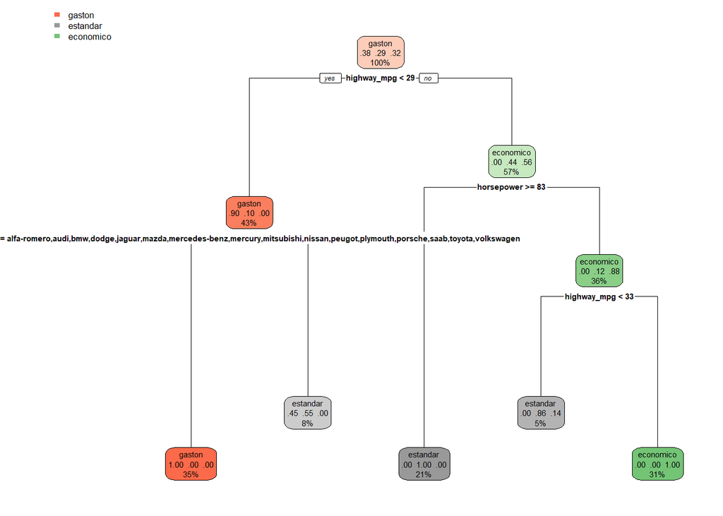

```r
modelo1_clas <- rpart(consumoCat~.,data = train,method = "class")
rpart.plot(modelo1_clas)
```

**Predicción con el modelo**

```r
predm1C <- predict(modelo1_clas,newdata = test)
predm1C <-apply(predm1C, 1, function(x) colnames(predm1C)[which.max(x)])
predm1C <- as.factor(predm1C)
cfm1c <- confusionMatrix(test$consumoCat, predm1C)
```

```r
profundidades <- expand.grid(maxdepth = 2:10)

system.time (modelo2C<-train(consumoCat~.,
                data=train,
                method="rpart2",
                tuneLength = 10,
                tuneGrid = profundidades,
                trControl = controlcv,
                metric = "Accuracy",
                na.action = na.pass
               )
)
```

```
##    user  system elapsed
##    1.00    0.02    1.03
```

```r
modelo2C
```

```
## CART
##
## 143 samples
##  24 predictor
##   3 classes: 'gaston', 'estandar', 'economico'
##
## No pre-processing
## Resampling: Cross-Validated (10 fold)
## Summary of sample sizes: 129, 128, 129, 129, 128, 129, ...
## Resampling results across tuning parameters:
##
##   maxdepth  Accuracy   Kappa
##    2        0.8600000  0.7867213
##    3        0.8880952  0.8298690
##    4        0.8880952  0.8298690
##    5        0.8880952  0.8298690
##    6        0.8880952  0.8298690
##    7        0.8880952  0.8298690
##    8        0.8880952  0.8298690
##    9        0.8880952  0.8298690
##   10        0.8880952  0.8298690
##
## Accuracy was used to select the optimal model using the largest value.
## The final value used for the model was maxdepth = 3.
```

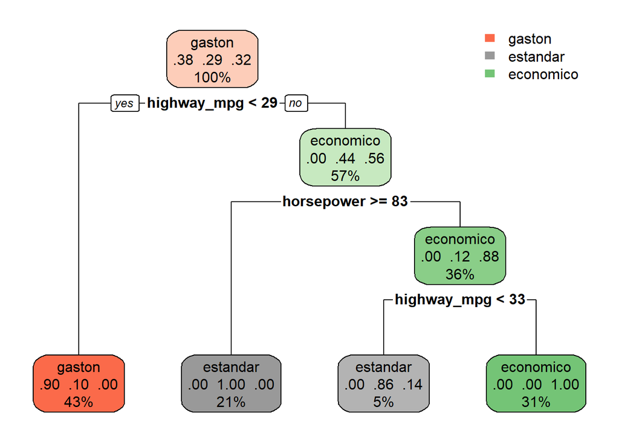

```r
rpart.plot(modelo2C$finalModel)
```

```r
predm2C <- predict(modelo2C,newdata = test)
predm2C <- as.factor(predm2C)
cfm2c <- confusionMatrix(test$consumoCat, predm2C)
cfm2c
```

```
## Confusion Matrix and Statistics
##
##            Reference
## Prediction  gaston estandar economico
##   gaston        15        0         0
##   estandar       5       21         0
##   economico      0        5        16
##
## Overall Statistics
##
##                Accuracy : 0.8387
##                  95% CI : (0.7233, 0.9198)
##     No Information Rate : 0.4194
##     P-Value [Acc > NIR] : 1.28e-11
##
##                   Kappa : 0.7551
##
##  Mcnemar's Test P-Value : NA
##
## Statistics by Class:
##
##                      Class: gaston Class: estandar Class: economico
## Sensitivity                 0.7500          0.8077           1.0000
## Specificity                 1.0000          0.8611           0.8913
## Pos Pred Value              1.0000          0.8077           0.7619
## Neg Pred Value              0.8936          0.8611           1.0000
## Prevalence                  0.3226          0.4194           0.2581
## Detection Rate              0.2419          0.3387           0.2581
## Detection Prevalence        0.2419          0.4194           0.3387
## Balanced Accuracy           0.8750          0.8344           0.9457
```

Como se puede observar el accuracy no mejoró mucho por lo que el mejor modelo es un árbo con profundidad de 3.

```r
save(carros,file = "carros.RData")
```